# Day 1 - Getting started

January, 2018

## Introduction

- Day 1 - Getting started
- Day 2 - Functions & Spark
- Day 3 - Tidyverse
- Day 4 - Plotly
- Day 5 - Shiny Introduction
- Day 6 - Reactivity
- Day 7 - Modules
- Day 8 - Shiny Project

## Day 1 - Getting started

## Day 1 - Agenda

- Why R?
- Installing R
- Cloning git repo
- Installing Packages
- Finding Help

## Installing R & Rstudio

- Go to your internet browser and download [R](https://cran.r-project.org/bin/windows/base/R-3.4.3-win.exe)
- Also, download [RStudio](https://download1.rstudio.org/RStudio-1.1.383.exe)
- Run the R exe and wait for it to finish installing
- Once done, go ahead and install RStudio

## Installing Git & Tortise Git

- Go to your internet browser and download [Git](https://github.com/git-for-windows/git/releases/download/v2.15.1.windows.2/Git-2.15.1.2-64-bit.exe)
- Also, download [TortoiseGit](https://download.tortoisegit.org/tgit/2.5.0.0/TortoiseGit-2.5.0.0-64bit.msi)
- Install Git and then TortoiseGit

## Setup git proxy

Right-click > TortiseGit > Settings > Network. Then enter your username and password.

[figure not shown]

## Clone git repo

Right-click > Git Clone > **https://github.com/gbisschoff/grad-training.git**

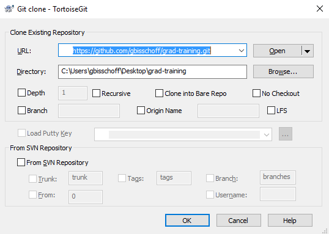

## Installing Packages

- To Install packages you can run `install.packages("package name")`
- Lets try by installing the most important package we will be using later in the course; **tidyverse**
- Tidyverse is a set of packages that makes data science easy
- `install.packages("tidyverse")`
- You can also use click *Install* button on the *Packages* tab, located on the bottom right

## Finding Help

- To find help on a function or package that you have already installed, go to the *Help* tab on the bottom right and search for a package name or function in the search box
- Alternatively, you can run `??function_name`. E.g. `??tidyverse` -There are also many ['cheatsheets'](https://www.rstudio.com/resources/cheatsheets/) available that gives you the need-to-know information on some of the most popular packages. Some can be found under **Help > Cheatsheets**

## Exercise 1

Use the Base-r cheatsheet to generate loan data. Each account has:

- *id* - which is used to identify a specific account (just make it account-1 for now)
- *segment* - which is randomly generated from (A,B,C)
- *start_balance* - which is randomly generated between (5000,6000)
- *interest_rate* - An annual rate randomly generated between (5%,20%) converted to a monthly rate
- *n* - The term of the loan a fixed 60 months

## Exercise 1

- calculate the monthly installment as:  
  \(pmt=start\_balance\times \frac{r\times(1+r)^n}{(1+r)^n-1}\)
- calculate contractual outstanding balance as:  
  \(balance\_contractual_0=start\_balance\times(1+r) - pmt\) \(balance\_contractual_t=balance\_contractual_{t-1}\times(1+r) - pmt\)

## Exercise 1

- calculate a probability of default term structure as:  
  `PD<-dlnorm(seq(0.05,3,by = 0.05), meanlog = 0, sdlog = 1, log = FALSE)/6`

loop over \(t \subset (1,n)\) and create vectors for:

- a flag to see if the person made the payment as: \(made\_payment_t<-I(1-PD_t \ge U)\)
- actual outstanding balance as:  
  \(balance\_actual_0=start\_balance\times(1+r) - pmt\times made\_payment_0\) \(balance\_actual_t=balance\_actual_{t-1}\times(1+r) - pmt\times made\_payment_t\)

## Exercise 1

Create a dataset containing the columns:

- id,
- segment,
- start_balance, -interest_rate,
- n,
- age as a vector from 1 to n
- pmt,
- balance_contractual
- made_payment
- balance_actual,
- arrears_amt as balance_contractual - balance_actual
- cd_bucket as -ceiling(arrears_amt/pmt)

## Example solution

See **Data > transition_data.csv** for example output.